# TEX vs. MIA

2023-03-04

Load packages:

```r
library(tidyverse)
library(readr)
library(baseballr)
library(plotly)
library(CalledStrike)
library(knitr)
library(kableExtra)
library(rpart)
```

Load data:

```r
# filter out columns with majority NAs, or variables not needed for this analysis
clean_tm <- TEX_MIA %>%
  dplyr::select(pitch_type:pitcher...8, description, zone:type, balls, strikes, plate_x, plate_z, outs_when_up:inning_topbot, sz_top, sz_bot, effective_speed,
                release_spin_rate, game_pk, release_pos_y, at_bat_number:post_bat_score, spin_axis:delta_run_exp) %>%
  mutate(id = 1:273)

# filter to pitches of interest and add in sz_l and sz_r
TEX_MIA_filtered <- clean_tm %>%
  filter(description %in% c("ball", "blocked_ball", "called_strike")) %>%
  mutate(sz_l = -8.5/12, sz_r = 8.5/12)
```

**Score:**

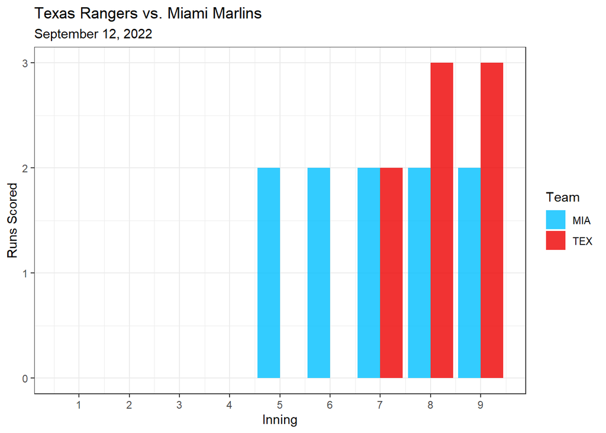

```r
tm_scores <- TEX_MIA %>%
  group_by(inning) %>%
  summarise(MIA = max(home_score),
            TEX = max(away_score)) %>%
  pivot_longer(cols = MIA:TEX,
               names_to = "team",
               values_to = "score")
tm_scores %>%
  ggplot(aes(x = inning, y = score, fill = team)) +
  geom_col(alpha = 0.8, position = "dodge") +
  labs(title = "Texas Rangers vs. Miami Marlins",
       subtitle = "September 12, 2022",
       x = "Inning", y = "Runs Scored", fill = "Team") +
  theme_bw() +
  scale_x_continuous(breaks = 1:9) +
  scale_fill_manual(values = c("deepskyblue", "red2"))
```

### Finding the incorrect calls:

```r
long_tm <- TEX_MIA_filtered %>%
  mutate(new_sz_top = sz_top + b_rad,
         new_sz_bot = sz_bot - b_rad,
         new_sz_l = sz_l - b_rad,
         new_sz_r = sz_r + b_rad)

calc_long_tm <- long_tm %>%
  mutate(true = case_when(plate_z > new_sz_top | plate_z < new_sz_bot ~ "ball",
                          plate_x > new_sz_r | plate_x < new_sz_l ~ "ball",
                          TRUE ~ "strike"))
table(calc_long_tm$true)
```

```
##
##   ball strike
##     95     39
```

The predicted number of balls and strikes is very close to the actual number.

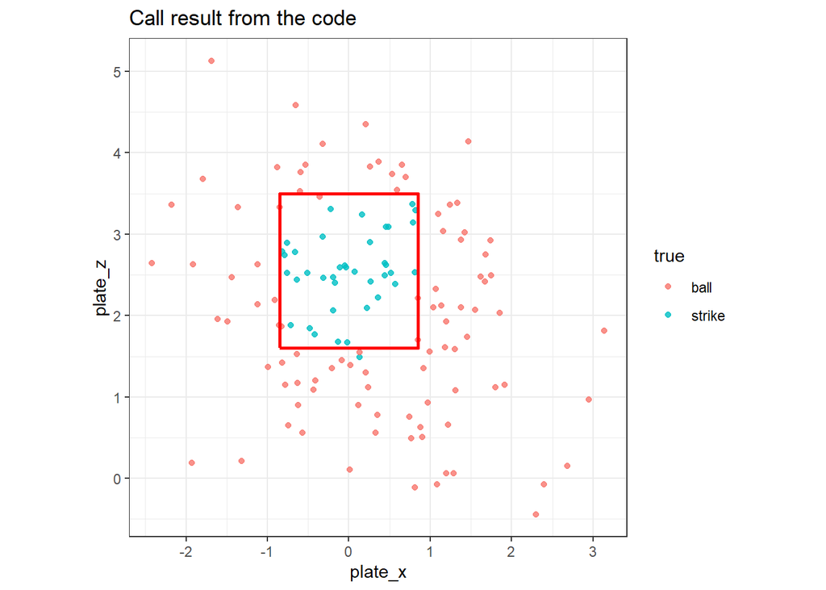

```r
calc_long_tm %>%
  ggplot(aes(x = plate_x, y = plate_z, color = true)) +
  geom_point(alpha = .8) +
  labs(title = "Call result from the code") +
  theme_bw() +
  add_zone() + coord_fixed(ratio = 1)
```

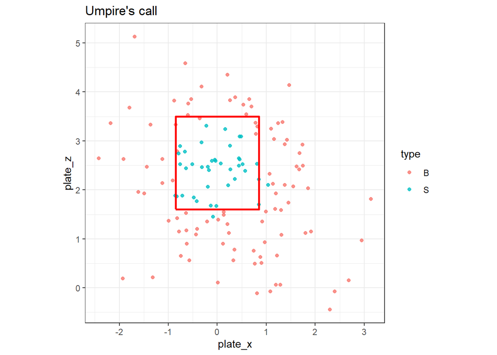

```r
calc_long_tm %>%
  ggplot(aes(x = plate_x, y = plate_z, color = type)) +
  geom_point(alpha = .8) +
  labs(title = "Umpire's call") +
  theme_bw() +
  add_zone() + coord_fixed(ratio = 1)
```

```r
identify_tm <- calc_long_tm %>%
  mutate(call = case_when((type == "B" & true == "ball") ~ "pass",
                          (type == "S" & true == "strike") ~ "pass",
                          TRUE ~ "fail"))
table(identify_tm$call)
```

```
##
## fail pass
##   11  123
```

All pitches that were called_strike, ball, and blocked_ball

```r
fill4 <- which(identify_tm$call == "fail")

identify_tm %>%
  dplyr::select(-des) %>% # took out this variable cause it was long
  kable() %>%
  kable_styling("striped") %>%
  row_spec(fill4, background = "skyblue") %>%
  scroll_box(height = "500px", width = "100%")
```

| pitch_type | game_date | release_speed | release_pos_x | release_pos_z | player_name | batter | pitcher…8 | description | zone | game_type | stand | p_throws | home_team | away_team | type | balls | strikes | plate_x | plate_z | outs_when_up | inning | inning_topbot | sz_top | sz_bot | effective_speed | release_spin_rate | game_pk | release_pos_y | at_bat_number | … |
| --- | --- | --- | --- | --- | --- | --- | --- | --- | --- | --- | --- | --- | --- | --- | --- | --- | --- | --- | --- | --- | --- | --- | --- | --- | --- | --- | --- | --- | --- | --- |
| FF | 9/12/2022 | 95.4 | 3.28 | 5.56 | Rogers, Trevor | 543760 | 669432 | called_strike | 14 | R | R | L | MIA | TEX | S | 0 | 0 | 0.85 | 1.70 | 0 | 1 | Top | 3.24 | 1.57 | 95.9 | 2503 | 661420 | 53.70 | 1 | … |
| CH | 9/12/2022 | 85.3 | 3.33 | 5.36 | Rogers, Trevor | 543760 | 669432 | ball | 14 | R | R | L | MIA | TEX | B | 0 | 1 | 1.85 | 2.03 | 0 | 1 | Top | 3.26 | 1.63 | 86.3 | 1290 | 661420 | 53.57 | 1 | … |
| FF | 9/12/2022 | 96.5 | 3.21 | 5.63 | Rogers, Trevor | 608369 | 669432 | ball | 8 | R | L | L | MIA | TEX | B | 0 | 0 | 0.13 | 1.49 | 1 | 1 | Top | 3.36 | 1.51 | 96.0 | 2539 | 661420 | 54.06 | 2 | … |
| FF | 9/12/2022 | 95.7 | 3.27 | 5.60 | Rogers, Trevor | 663993 | 669432 | called_strike | 6 | R | L | L | MIA | TEX | S | 0 | 0 | 0.44 | 2.64 | 2 | 1 | Top | 3.34 | 1.56 | 94.8 | 2700 | 661420 | 54.24 | 3 | … |
| CH | 9/12/2022 | 87.5 | 3.17 | 5.47 | Rogers, Trevor | 666969 | 669432 | called_strike | 4 | R | R | L | MIA | TEX | S | 0 | 0 | -0.31 | 2.46 | 2 | 1 | Top | 3.27 | 1.67 | 88.1 | 1559 | 661420 | 53.54 | 4 | … |
| SI | 9/12/2022 | 92.8 | -1.66 | 5.96 | Otto, Glenn | 542932 | 657248 | called_strike | 6 | R | R | R | MIA | TEX | S | 0 | 1 | 0.57 | 2.39 | 0 | 1 | Bot | 3.26 | 1.49 | 93.6 | 2051 | 661420 | 53.56 | 5 | … |
| SI | 9/12/2022 | 92.2 | -1.69 | 6.08 | Otto, Glenn | 605119 | 657248 | ball | 13 | R | R | R | MIA | TEX | B | 0 | 0 | -1.44 | 2.47 | 1 | 1 | Bot | 3.39 | 1.63 | 92.6 | 2088 | 661420 | 53.78 | 6 | … |
| KC | 9/12/2022 | 79.9 | -1.57 | 6.03 | Otto, Glenn | 643265 | 657248 | called_strike | 5 | R | R | R | MIA | TEX | S | 0 | 0 | -0.03 | 2.59 | 2 | 1 | Bot | 3.42 | 1.73 | 80.5 | 2364 | 661420 | 53.78 | 7 | … |
| FF | 9/12/2022 | 95.1 | 3.28 | 5.54 | Rogers, Trevor | 664029 | 669432 | ball | 14 | R | R | L | MIA | TEX | B | 0 | 0 | 0.21 | 1.30 | 0 | 2 | Top | 3.24 | 1.62 | 95.1 | 2464 | 661420 | 53.86 | 8 | … |
| FF | 9/12/2022 | 95.1 | 3.29 | 5.64 | Rogers, Trevor | 664029 | 669432 | ball | 12 | R | R | L | MIA | TEX | B | 1 | 0 | 1.16 | 3.04 | 0 | 2 | Top | 3.26 | 1.62 | 94.9 | 2442 | 661420 | 54.07 | 8 | … |
| FF | 9/12/2022 | 94.9 | 3.21 | 5.64 | Rogers, Trevor | 664029 | 669432 | called_strike | 13 | R | R | L | MIA | TEX | S | 2 | 0 | -0.09 | 1.45 | 0 | 2 | Top | 3.30 | 1.58 | 95.0 | 2510 | 661420 | 53.80 | 8 | … |
| CH | 9/12/2022 | 86.9 | 3.18 | 5.53 | Rogers, Trevor | 664029 | 669432 | ball | 14 | R | R | L | MIA | TEX | B | 2 | 1 | 1.14 | 2.12 | 0 | 2 | Top | 3.23 | 1.62 | 87.5 | 1447 | 661420 | 53.73 | 8 | … |
| CH | 9/12/2022 | 87.9 | 3.12 | 5.40 | Rogers, Trevor | 673962 | 669432 | ball | 13 | R | R | L | MIA | TEX | B | 0 | 0 | -0.82 | 1.42 | 1 | 2 | Top | 3.40 | 1.59 | 88.7 | 1588 | 661420 | 53.45 | 9 | … |
| FF | 9/12/2022 | 96.6 | 3.20 | 5.59 | Rogers, Trevor | 673962 | 669432 | ball | 13 | R | R | L | MIA | TEX | B | 1 | 0 | -0.21 | 1.35 | 1 | 2 | Top | 3.53 | 1.59 | 96.6 | 2600 | 661420 | 53.78 | 9 | … |
| CH | 9/12/2022 | 85.9 | 3.16 | 5.45 | Rogers, Trevor | 669087 | 669432 | ball | 14 | R | R | L | MIA | TEX | B | 0 | 0 | 1.07 | 2.33 | 2 | 2 | Top | 3.47 | 1.66 | 86.7 | 1401 | 661420 | 53.57 | 10 | … |
| FF | 9/12/2022 | 95.9 | 3.04 | 5.75 | Rogers, Trevor | 669087 | 669432 | ball | 3 | R | R | L | MIA | TEX | B | 1 | 0 | 0.78 | 3.37 | 2 | 2 | Top | 3.62 | 1.63 | 95.9 | 2589 | 661420 | 53.97 | 10 | … |
| FF | 9/12/2022 | 95.3 | 3.13 | 5.64 | Rogers, Trevor | 669087 | 669432 | called_strike | 14 | R | R | L | MIA | TEX | S | 2 | 0 | 1.04 | 2.10 | 2 | 2 | Top | 3.66 | 1.70 | 95.2 | 2510 | 661420 | 53.98 | 10 | … |
| FF | 9/12/2022 | 95.6 | 3.20 | 5.62 | Rogers, Trevor | 669087 | 669432 | ball | 14 | R | R | L | MIA | TEX | B | 2 | 2 | 0.02 | 1.39 | 2 | 2 | Top | 3.56 | 1.66 | 95.5 | 2545 | 661420 | 53.87 | 10 | … |
| FF | 9/12/2022 | 96.3 | 3.08 | 5.70 | Rogers, Trevor | 669087 | 669432 | ball | 12 | R | R | L | MIA | TEX | B | 3 | 2 | 1.10 | 3.25 | 2 | 2 | Top | 3.57 | 1.66 | 96.3 | 2612 | 661420 | 53.86 | 10 | … |
| FF | 9/12/2022 | 94.5 | 3.06 | 5.49 | Rogers, Trevor | 669701 | 669432 | called_strike | 5 | R | L | L | MIA | TEX | S | 0 | 0 | -0.19 | 2.06 | 2 | 2 | Top | 2.78 | 1.45 | 94.1 | 2573 | 661420 | 54.03 | 11 | … |
| FF | 9/12/2022 | 91.5 | -1.78 | 5.90 | Otto, Glenn | 668709 | 657248 | ball | 14 | R | L | R | MIA | TEX | B | 0 | 0 | 1.38 | 2.10 | 0 | 2 | Bot | 3.36 | 1.72 | 92.6 | 2297 | 661420 | 53.53 | 12 | … |
| SI | 9/12/2022 | 93.3 | -1.72 | 6.00 | Otto, Glenn | 641779 | 657248 | called_strike | 3 | R | R | R | MIA | TEX | S | 0 | 1 | 0.46 | 3.09 | 1 | 2 | Bot | 3.35 | 1.71 | 94.0 | 2325 | 661420 | 53.73 | 13 | … |
| SL | 9/12/2022 | 82.6 | -1.97 | 5.96 | Otto, Glenn | 641779 | 657248 | ball | 14 | R | R | R | MIA | TEX | B | 0 | 2 | 0.88 | 0.63 | 1 | 2 | Bot | 3.35 | 1.71 | 82.9 | 2616 | 661420 | 53.82 | 13 | … |
| SL | 9/12/2022 | 81.4 | -1.80 | 5.99 | Otto, Glenn | 641779 | 657248 | ball | 11 | R | R | R | MIA | TEX | B | 1 | 2 | -0.60 | 3.53 | 1 | 2 | Bot | 3.27 | 1.71 | 81.5 | 2437 | 661420 | 53.99 | 13 | … |
| SI | 9/12/2022 | 92.5 | -1.54 | 6.03 | Otto, Glenn | 500743 | 657248 | called_strike | 1 | R | R | R | MIA | TEX | S | 0 | 0 | -0.32 | 2.97 | 2 | 2 | Bot | 3.23 | 1.60 | 92.6 | 2202 | 661420 | 53.78 | 14 | … |
| FF | 9/12/2022 | 93.9 | 3.09 | 5.67 | Rogers, Trevor | 669352 | 669432 | ball | 11 | R | R | L | MIA | TEX | B | 0 | 0 | -0.53 | 3.85 | 0 | 3 | Top | 3.30 | 1.55 | 94.1 | 2601 | 661420 | 53.74 | 15 | … |
| CH | 9/12/2022 | 86.6 | 3.23 | 5.48 | Rogers, Trevor | 543760 | 669432 | called_strike | 6 | R | R | L | MIA | TEX | S | 0 | 0 | 0.44 | 2.49 | 1 | 3 | Top | 3.24 | 1.63 | 87.0 | 1296 | 661420 | 53.73 | 16 | … |
| KC | 9/12/2022 | 81.9 | -1.55 | 5.94 | Otto, Glenn | 666464 | 657248 | ball | 14 | R | R | R | MIA | TEX | B | 0 | 0 | 2.68 | 0.15 | 1 | 3 | Bot | 3.69 | 1.74 | 82.2 | 2577 | 661420 | 53.63 | 19 | … |
| FF | 9/12/2022 | 93.0 | -1.72 | 5.93 | Otto, Glenn | 666464 | 657248 | ball | 14 | R | R | R | MIA | TEX | B | 1 | 0 | 0.90 | 0.51 | 1 | 3 | Bot | 3.62 | 1.74 | 94.3 | 2201 | 661420 | 53.51 | 19 | … |
| FF | 9/12/2022 | 91.2 | -1.56 | 5.92 | Otto, Glenn | 666464 | 657248 | ball | 14 | R | R | R | MIA | TEX | B | 2 | 0 | 1.55 | 2.07 | 1 | 3 | Bot | 3.60 | 1.74 | 92.4 | 2276 | 661420 | 53.53 | 19 | … |

[output cut: 104 more lines]

Only the ones identified as incorrect:

```r
incorrect_tm <- identify_tm %>%
  filter(call == "fail")
incorrect_tm %>%
  dplyr::select(-des) %>% # took out this variable cause it was long
  kable() %>%
  kable_styling("striped") %>%
  scroll_box(height = "500px", width = "100%")
```

| pitch_type | game_date | release_speed | release_pos_x | release_pos_z | player_name | batter | pitcher…8 | description | zone | game_type | stand | p_throws | home_team | away_team | type | balls | strikes | plate_x | plate_z | outs_when_up | inning | inning_topbot | sz_top | sz_bot | effective_speed | release_spin_rate | game_pk | release_pos_y | at_bat_number | … |
| --- | --- | --- | --- | --- | --- | --- | --- | --- | --- | --- | --- | --- | --- | --- | --- | --- | --- | --- | --- | --- | --- | --- | --- | --- | --- | --- | --- | --- | --- | --- |
| FF | 9/12/2022 | 95.4 | 3.28 | 5.56 | Rogers, Trevor | 543760 | 669432 | called_strike | 14 | R | R | L | MIA | TEX | S | 0 | 0 | 0.85 | 1.70 | 0 | 1 | Top | 3.24 | 1.57 | 95.9 | 2503 | 661420 | 53.70 | 1 | … |
| FF | 9/12/2022 | 96.5 | 3.21 | 5.63 | Rogers, Trevor | 608369 | 669432 | ball | 8 | R | L | L | MIA | TEX | B | 0 | 0 | 0.13 | 1.49 | 1 | 1 | Top | 3.36 | 1.51 | 96.0 | 2539 | 661420 | 54.06 | 2 | … |
| FF | 9/12/2022 | 94.9 | 3.21 | 5.64 | Rogers, Trevor | 664029 | 669432 | called_strike | 13 | R | R | L | MIA | TEX | S | 2 | 0 | -0.09 | 1.45 | 0 | 2 | Top | 3.30 | 1.58 | 95.0 | 2510 | 661420 | 53.80 | 8 | … |
| FF | 9/12/2022 | 95.9 | 3.04 | 5.75 | Rogers, Trevor | 669087 | 669432 | ball | 3 | R | R | L | MIA | TEX | B | 1 | 0 | 0.78 | 3.37 | 2 | 2 | Top | 3.62 | 1.63 | 95.9 | 2589 | 661420 | 53.97 | 10 | … |
| FF | 9/12/2022 | 95.3 | 3.13 | 5.64 | Rogers, Trevor | 669087 | 669432 | called_strike | 14 | R | R | L | MIA | TEX | S | 2 | 0 | 1.04 | 2.10 | 2 | 2 | Top | 3.66 | 1.70 | 95.2 | 2510 | 661420 | 53.98 | 10 | … |
| FF | 9/12/2022 | 94.7 | 3.04 | 5.60 | Rogers, Trevor | 663993 | 669432 | ball | 4 | R | L | L | MIA | TEX | B | 1 | 2 | -0.82 | 2.79 | 0 | 4 | Top | 3.38 | 1.54 | 94.8 | 2644 | 661420 | 53.89 | 22 | … |
| FF | 9/12/2022 | 95.1 | 3.18 | 5.64 | Rogers, Trevor | 673962 | 669432 | called_strike | 7 | R | R | L | MIA | TEX | S | 2 | 2 | -0.83 | 1.87 | 0 | 5 | Top | 3.55 | 1.59 | 94.9 | 2558 | 661420 | 54.00 | 29 | … |
| FF | 9/12/2022 | 94.3 | 3.06 | 5.59 | Rogers, Trevor | 669701 | 669432 | called_strike | 13 | R | L | L | MIA | TEX | S | 0 | 1 | -0.86 | 1.88 | 2 | 5 | Top | 3.23 | 1.64 | 94.5 | 2488 | 661420 | 53.83 | 31 | … |
| SL | 9/12/2022 | 79.5 | -1.85 | 5.88 | Otto, Glenn | 607732 | 657248 | called_strike | 14 | R | R | R | MIA | TEX | S | 0 | 0 | 0.85 | 2.21 | 0 | 5 | Bot | 3.36 | 1.61 | 79.7 | 2404 | 661420 | 53.83 | 33 | … |
| SL | 9/12/2022 | 83.6 | 3.12 | 5.72 | Okert, Steven | 608369 | 595345 | ball | 3 | R | L | L | MIA | TEX | B | 1 | 0 | 0.82 | 3.29 | 2 | 8 | Top | 3.53 | 1.63 | 83.2 | 2375 | 661420 | 54.37 | 57 | … |
| SL | 9/12/2022 | 82.2 | 3.01 | 5.66 | Okert, Steven | 664029 | 595345 | ball | 3 | R | R | L | MIA | TEX | B | 3 | 2 | 0.79 | 3.14 | 2 | 8 | Top | 3.21 | 1.55 | 82.1 | 2260 | 661420 | 54.28 | 60 | … |

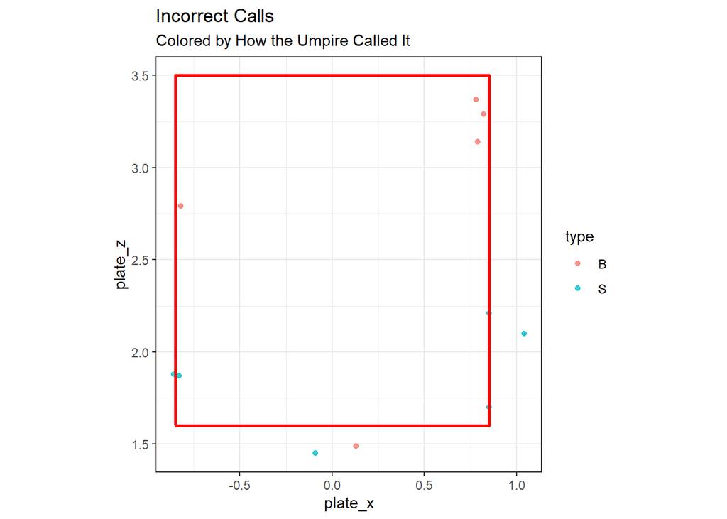

```r
incorrect_tm %>%
  ggplot(aes(x = plate_x, y = plate_z, color = type)) +
  geom_point(alpha = .8) +
  labs(title = "Incorrect Calls", subtitle = "Colored by How the Umpire Called It") +
  theme_bw() +
  add_zone() + coord_fixed(ratio = 1)
```

Finding counts of incorrect calls:

```r
incorrect_tm %>%
  group_by(balls, strikes) %>%
  summarize(n())
```

```
## # A tibble: 7 × 3
## # Groups:   balls [4]
##   balls strikes `n()`
##   <dbl>   <dbl> <int>
## 1     0       0     3
## 2     0       1     1
## 3     1       0     2
## 4     1       2     1
## 5     2       0     2
## 6     2       2     1
## 7     3       2     1
```

## Predictive Modeling

### Predicting Incorrect Calls

```r
model_tm <- rpart(type ~ outs_when_up + inning + home_score + away_score + balls + strikes, data = identify_tm)
predictions_tm <- as.data.frame(predict(model_tm))
predictions_tm <- predictions_tm %>%
  mutate(predict_call = case_when(B > S ~ "ball",
                                  S > B ~ "strike"))
table(predictions_tm$predict_call)
```

```
##
##   ball strike
##    103     31
```

Less accurate than previous way

Compare predicted call to actual call

```r
# add predictions to the data frame
pred_m_tm <- calc_long_tm %>%
  mutate(predict_call = predictions_tm$predict_call)

# find the incorrect calls
identify_pm_tm <- pred_m_tm %>%
  mutate(call = case_when((type == "B" & true == "ball") ~ "pass",
                          (type == "S" & true == "strike") ~ "pass",
                          TRUE ~ "fail"))
table(identify_pm_tm$call)
```

```
##
## fail pass
##   11  123
```

### Predicting Individual Play Results

```r
model_outcome_tm <- rpart(description ~ call + true + outs_when_up + inning + bat_score + fld_score + balls +
                          strikes + plate_x + plate_z, data = all_added_tm)
predictions_outcome_tm <- as.data.frame(predict(model_outcome_tm))

# get the column names of the largest values
predictions_outcome_tm$highest<- (colnames(predictions_outcome_tm)[max.col(predictions_outcome_tm)])

# add in to data frame
all_added_tm <- all_added_tm %>%
  mutate(pred_outcome = predictions_outcome_tm$highest)
```

Full data with incorrect calls highlighted:

```r
fill5 <- which(all_added_tm$call == "fail")
all_added_tm %>%
  dplyr::select(-des) %>%
  kable %>%
  kable_styling("striped") %>%
  row_spec(fill5, background = "skyblue") %>%
  scroll_box(height = "500px")
```

| pitch_type | game_date | release_speed | release_pos_x | release_pos_z | player_name | batter | pitcher…8 | description | zone | game_type | stand | p_throws | home_team | away_team | type | balls | strikes | plate_x | plate_z | outs_when_up | inning | inning_topbot | sz_top | sz_bot | effective_speed | release_spin_rate | game_pk | release_pos_y | at_bat_number | … |
| --- | --- | --- | --- | --- | --- | --- | --- | --- | --- | --- | --- | --- | --- | --- | --- | --- | --- | --- | --- | --- | --- | --- | --- | --- | --- | --- | --- | --- | --- | --- |
| FF | 9/12/2022 | 95.4 | 3.28 | 5.56 | Rogers, Trevor | 543760 | 669432 | called_strike | 14 | R | R | L | MIA | TEX | S | 0 | 0 | 0.85 | 1.70 | 0 | 1 | Top | 3.24 | 1.57 | 95.9 | 2503 | 661420 | 53.70 | 1 | … |
| CH | 9/12/2022 | 85.3 | 3.33 | 5.36 | Rogers, Trevor | 543760 | 669432 | ball | 14 | R | R | L | MIA | TEX | B | 0 | 1 | 1.85 | 2.03 | 0 | 1 | Top | 3.26 | 1.63 | 86.3 | 1290 | 661420 | 53.57 | 1 | … |
| FF | 9/12/2022 | 96.5 | 3.21 | 5.63 | Rogers, Trevor | 608369 | 669432 | ball | 8 | R | L | L | MIA | TEX | B | 0 | 0 | 0.13 | 1.49 | 1 | 1 | Top | 3.36 | 1.51 | 96.0 | 2539 | 661420 | 54.06 | 2 | … |
| FF | 9/12/2022 | 95.7 | 3.27 | 5.60 | Rogers, Trevor | 663993 | 669432 | called_strike | 6 | R | L | L | MIA | TEX | S | 0 | 0 | 0.44 | 2.64 | 2 | 1 | Top | 3.34 | 1.56 | 94.8 | 2700 | 661420 | 54.24 | 3 | … |
| CH | 9/12/2022 | 87.5 | 3.17 | 5.47 | Rogers, Trevor | 666969 | 669432 | called_strike | 4 | R | R | L | MIA | TEX | S | 0 | 0 | -0.31 | 2.46 | 2 | 1 | Top | 3.27 | 1.67 | 88.1 | 1559 | 661420 | 53.54 | 4 | … |
| SI | 9/12/2022 | 92.8 | -1.66 | 5.96 | Otto, Glenn | 542932 | 657248 | called_strike | 6 | R | R | R | MIA | TEX | S | 0 | 1 | 0.57 | 2.39 | 0 | 1 | Bot | 3.26 | 1.49 | 93.6 | 2051 | 661420 | 53.56 | 5 | … |
| SI | 9/12/2022 | 92.2 | -1.69 | 6.08 | Otto, Glenn | 605119 | 657248 | ball | 13 | R | R | R | MIA | TEX | B | 0 | 0 | -1.44 | 2.47 | 1 | 1 | Bot | 3.39 | 1.63 | 92.6 | 2088 | 661420 | 53.78 | 6 | … |
| KC | 9/12/2022 | 79.9 | -1.57 | 6.03 | Otto, Glenn | 643265 | 657248 | called_strike | 5 | R | R | R | MIA | TEX | S | 0 | 0 | -0.03 | 2.59 | 2 | 1 | Bot | 3.42 | 1.73 | 80.5 | 2364 | 661420 | 53.78 | 7 | … |
| FF | 9/12/2022 | 95.1 | 3.28 | 5.54 | Rogers, Trevor | 664029 | 669432 | ball | 14 | R | R | L | MIA | TEX | B | 0 | 0 | 0.21 | 1.30 | 0 | 2 | Top | 3.24 | 1.62 | 95.1 | 2464 | 661420 | 53.86 | 8 | … |
| FF | 9/12/2022 | 95.1 | 3.29 | 5.64 | Rogers, Trevor | 664029 | 669432 | ball | 12 | R | R | L | MIA | TEX | B | 1 | 0 | 1.16 | 3.04 | 0 | 2 | Top | 3.26 | 1.62 | 94.9 | 2442 | 661420 | 54.07 | 8 | … |
| FF | 9/12/2022 | 94.9 | 3.21 | 5.64 | Rogers, Trevor | 664029 | 669432 | called_strike | 13 | R | R | L | MIA | TEX | S | 2 | 0 | -0.09 | 1.45 | 0 | 2 | Top | 3.30 | 1.58 | 95.0 | 2510 | 661420 | 53.80 | 8 | … |
| CH | 9/12/2022 | 86.9 | 3.18 | 5.53 | Rogers, Trevor | 664029 | 669432 | ball | 14 | R | R | L | MIA | TEX | B | 2 | 1 | 1.14 | 2.12 | 0 | 2 | Top | 3.23 | 1.62 | 87.5 | 1447 | 661420 | 53.73 | 8 | … |
| CH | 9/12/2022 | 87.9 | 3.12 | 5.40 | Rogers, Trevor | 673962 | 669432 | ball | 13 | R | R | L | MIA | TEX | B | 0 | 0 | -0.82 | 1.42 | 1 | 2 | Top | 3.40 | 1.59 | 88.7 | 1588 | 661420 | 53.45 | 9 | … |
| FF | 9/12/2022 | 96.6 | 3.20 | 5.59 | Rogers, Trevor | 673962 | 669432 | ball | 13 | R | R | L | MIA | TEX | B | 1 | 0 | -0.21 | 1.35 | 1 | 2 | Top | 3.53 | 1.59 | 96.6 | 2600 | 661420 | 53.78 | 9 | … |
| CH | 9/12/2022 | 85.9 | 3.16 | 5.45 | Rogers, Trevor | 669087 | 669432 | ball | 14 | R | R | L | MIA | TEX | B | 0 | 0 | 1.07 | 2.33 | 2 | 2 | Top | 3.47 | 1.66 | 86.7 | 1401 | 661420 | 53.57 | 10 | … |
| FF | 9/12/2022 | 95.9 | 3.04 | 5.75 | Rogers, Trevor | 669087 | 669432 | ball | 3 | R | R | L | MIA | TEX | B | 1 | 0 | 0.78 | 3.37 | 2 | 2 | Top | 3.62 | 1.63 | 95.9 | 2589 | 661420 | 53.97 | 10 | … |
| FF | 9/12/2022 | 95.3 | 3.13 | 5.64 | Rogers, Trevor | 669087 | 669432 | called_strike | 14 | R | R | L | MIA | TEX | S | 2 | 0 | 1.04 | 2.10 | 2 | 2 | Top | 3.66 | 1.70 | 95.2 | 2510 | 661420 | 53.98 | 10 | … |
| FF | 9/12/2022 | 95.6 | 3.20 | 5.62 | Rogers, Trevor | 669087 | 669432 | ball | 14 | R | R | L | MIA | TEX | B | 2 | 2 | 0.02 | 1.39 | 2 | 2 | Top | 3.56 | 1.66 | 95.5 | 2545 | 661420 | 53.87 | 10 | … |
| FF | 9/12/2022 | 96.3 | 3.08 | 5.70 | Rogers, Trevor | 669087 | 669432 | ball | 12 | R | R | L | MIA | TEX | B | 3 | 2 | 1.10 | 3.25 | 2 | 2 | Top | 3.57 | 1.66 | 96.3 | 2612 | 661420 | 53.86 | 10 | … |
| FF | 9/12/2022 | 94.5 | 3.06 | 5.49 | Rogers, Trevor | 669701 | 669432 | called_strike | 5 | R | L | L | MIA | TEX | S | 0 | 0 | -0.19 | 2.06 | 2 | 2 | Top | 2.78 | 1.45 | 94.1 | 2573 | 661420 | 54.03 | 11 | … |
| FF | 9/12/2022 | 91.5 | -1.78 | 5.90 | Otto, Glenn | 668709 | 657248 | ball | 14 | R | L | R | MIA | TEX | B | 0 | 0 | 1.38 | 2.10 | 0 | 2 | Bot | 3.36 | 1.72 | 92.6 | 2297 | 661420 | 53.53 | 12 | … |
| SI | 9/12/2022 | 93.3 | -1.72 | 6.00 | Otto, Glenn | 641779 | 657248 | called_strike | 3 | R | R | R | MIA | TEX | S | 0 | 1 | 0.46 | 3.09 | 1 | 2 | Bot | 3.35 | 1.71 | 94.0 | 2325 | 661420 | 53.73 | 13 | … |
| SL | 9/12/2022 | 82.6 | -1.97 | 5.96 | Otto, Glenn | 641779 | 657248 | ball | 14 | R | R | R | MIA | TEX | B | 0 | 2 | 0.88 | 0.63 | 1 | 2 | Bot | 3.35 | 1.71 | 82.9 | 2616 | 661420 | 53.82 | 13 | … |
| SL | 9/12/2022 | 81.4 | -1.80 | 5.99 | Otto, Glenn | 641779 | 657248 | ball | 11 | R | R | R | MIA | TEX | B | 1 | 2 | -0.60 | 3.53 | 1 | 2 | Bot | 3.27 | 1.71 | 81.5 | 2437 | 661420 | 53.99 | 13 | … |
| SI | 9/12/2022 | 92.5 | -1.54 | 6.03 | Otto, Glenn | 500743 | 657248 | called_strike | 1 | R | R | R | MIA | TEX | S | 0 | 0 | -0.32 | 2.97 | 2 | 2 | Bot | 3.23 | 1.60 | 92.6 | 2202 | 661420 | 53.78 | 14 | … |
| FF | 9/12/2022 | 93.9 | 3.09 | 5.67 | Rogers, Trevor | 669352 | 669432 | ball | 11 | R | R | L | MIA | TEX | B | 0 | 0 | -0.53 | 3.85 | 0 | 3 | Top | 3.30 | 1.55 | 94.1 | 2601 | 661420 | 53.74 | 15 | … |
| CH | 9/12/2022 | 86.6 | 3.23 | 5.48 | Rogers, Trevor | 543760 | 669432 | called_strike | 6 | R | R | L | MIA | TEX | S | 0 | 0 | 0.44 | 2.49 | 1 | 3 | Top | 3.24 | 1.63 | 87.0 | 1296 | 661420 | 53.73 | 16 | … |
| KC | 9/12/2022 | 81.9 | -1.55 | 5.94 | Otto, Glenn | 666464 | 657248 | ball | 14 | R | R | R | MIA | TEX | B | 0 | 0 | 2.68 | 0.15 | 1 | 3 | Bot | 3.69 | 1.74 | 82.2 | 2577 | 661420 | 53.63 | 19 | … |
| FF | 9/12/2022 | 93.0 | -1.72 | 5.93 | Otto, Glenn | 666464 | 657248 | ball | 14 | R | R | R | MIA | TEX | B | 1 | 0 | 0.90 | 0.51 | 1 | 3 | Bot | 3.62 | 1.74 | 94.3 | 2201 | 661420 | 53.51 | 19 | … |
| FF | 9/12/2022 | 91.2 | -1.56 | 5.92 | Otto, Glenn | 666464 | 657248 | ball | 14 | R | R | R | MIA | TEX | B | 2 | 0 | 1.55 | 2.07 | 1 | 3 | Bot | 3.60 | 1.74 | 92.4 | 2276 | 661420 | 53.53 | 19 | … |

[output cut: 243 more lines]

Just the incorrect calls and the predicted outcome:

```r
all_added_tm %>%
  filter(call == "fail") %>%
  dplyr::select(id, description, pred_outcome) %>%
  kable %>%
  kable_styling("striped")
```

| id | description | pred_outcome |
| --- | --- | --- |
| 1 | called_strike | ball |
| 5 | ball | called_strike |
| 23 | called_strike | ball |
| 33 | ball | called_strike |
| 34 | called_strike | ball |
| 77 | ball | called_strike |
| 103 | called_strike | ball |
| 109 | called_strike | ball |
| 115 | called_strike | ball |
| 202 | ball | called_strike |
| 221 | ball | called_strike |

### Further Application of These Results

#### Common Results of Each Count

The most frequent of each group is highlighted. This is looking at all of the data *except* the identified incorrect calls. A couple of them were tied for most frequent (those are specified below the table).

```r
all_added_tm %>%
  filter(call == "pass") %>%
  group_by(balls, strikes, description) %>%
  summarize(n()) %>%
  kable %>%
  kable_styling("striped") %>%
  row_spec(c(1, 15, 17, 26, 28, 35, 39:41, 43, 51, 55:56, 57:58, 60:62), background = "skyblue") %>%
  scroll_box(height = "500px")
```

| balls | strikes | description | n() |
| --- | --- | --- | --- |
| 0 | 0 | ball | 25 |
| 0 | 0 | blocked_ball | 3 |
| 0 | 0 | called_strike | 19 |
| 0 | 0 | foul | 5 |
| 0 | 0 | foul_bunt | 1 |
| 0 | 0 | foul_tip | 3 |
| 0 | 0 | hit_by_pitch | 1 |
| 0 | 0 | hit_into_play | 9 |
| 0 | 0 | swinging_strike | 4 |
| 0 | 1 | ball | 8 |
| 0 | 1 | blocked_ball | 2 |
| 0 | 1 | called_strike | 2 |
| 0 | 1 | foul | 4 |
| 0 | 1 | hit_into_play | 5 |
| 0 | 1 | swinging_strike | 11 |
| 0 | 1 | swinging_strike_blocked | 1 |
| 0 | 2 | ball | 8 |
| 0 | 2 | foul | 4 |
| 0 | 2 | foul_tip | 1 |
| 0 | 2 | hit_into_play | 6 |
| 0 | 2 | swinging_strike | 3 |
| 0 | 2 | swinging_strike_blocked | 1 |
| 1 | 0 | ball | 7 |
| 1 | 0 | called_strike | 6 |
| 1 | 0 | foul | 5 |
| 1 | 0 | hit_into_play | 8 |
| 1 | 0 | swinging_strike | 1 |
| 1 | 1 | ball | 7 |
| 1 | 1 | blocked_ball | 1 |
| 1 | 1 | called_strike | 2 |
| 1 | 1 | foul | 5 |
| 1 | 1 | hit_into_play | 5 |
| 1 | 1 | swinging_strike | 1 |
| 1 | 1 | swinging_strike_blocked | 1 |
| 1 | 2 | ball | 7 |
| 1 | 2 | foul | 3 |
| 1 | 2 | hit_into_play | 5 |
| 1 | 2 | swinging_strike | 4 |
| 2 | 0 | ball | 2 |
| 2 | 0 | called_strike | 2 |
| 2 | 0 | foul | 2 |
| 2 | 0 | swinging_strike | 1 |
| 2 | 1 | ball | 5 |
| 2 | 1 | blocked_ball | 1 |
| 2 | 1 | called_strike | 2 |
| 2 | 1 | foul | 2 |
| 2 | 1 | hit_into_play | 1 |
| 2 | 1 | swinging_strike | 4 |
| 2 | 2 | ball | 5 |
| 2 | 2 | blocked_ball | 1 |
| 2 | 2 | foul | 7 |
| 2 | 2 | hit_by_pitch | 1 |
| 2 | 2 | hit_into_play | 4 |
| 2 | 2 | swinging_strike | 4 |
| 3 | 0 | called_strike | 1 |
| 3 | 0 | foul | 1 |
| 3 | 1 | ball | 3 |
| 3 | 1 | foul | 3 |
| 3 | 1 | swinging_strike | 2 |
| 3 | 2 | ball | 4 |
| 3 | 2 | foul | 4 |
| 3 | 2 | hit_into_play | 4 |
| 3 | 2 | swinging_strike | 2 |

2-0 is tied between ball, called_strike, and foul. There are only two instances of a 3-0 count in this game, one resulted in called_strike the other foul. 3-1 is tied between ball and foul. 3-2 is tied between ball, foul, and hit_into_play.

According to the predictive modeling, **10 of the incorrect calls happened during the top of the inning (while Miami was pitching), and 1 call happened in the bottom of the inning (while Texas was pitching).**